# Assignment 2

## Submit as an HTML file

Print your name below

```python
# Write your answer
print("Angelica")
```

```
Angelica
```

(a) Import the pandas and matplotlib packages

```python
# Write your answer
import matplotlib.pyplot as plt
import pandas as pd
```

(b) Open the dataset "united_states_co2_emissions.csv" in the "data" folder

- Read it as a pandas object called "us_emissions"
- Note: This contains CO2 emissions (in kilotons) by the United States from 1960-2019.

It is compiled from various sources, including the United Nations Framework Convention  
on Climate Change (UNFCCC) and the International Energy Agency (IEA).

```python
# Write your answer
import pandas as pd
us_emissions = pd.read_csv("data/united_states_co2_emissions.csv")
```

(c) View the dataset and create a list of variable names

- Create a list, e.g. "variable_names = [ "name1", "name2"]"
- Manually type the names of the 2 variables

```python
# Write your answer
#year = ["2014", "2015", "2016", "2017", "2018", "2019"]
#total_emissions = ["5107209.9609375", "4990709.9609375", "4894500.0", "4819370.1171875", "4975310.05859375", "4817720.21484375"]
variable_names = ["year", "total_emissions"]
```

(d) Compute descriptive statistics for the 2nd variable in the dataset

- One way to do this is:

us_emissions["total_emissions"].describe()

- Do something similar, but with the list you created above.
- Substitute "total_emissions" with a command that automatically extracts the 2nd element in the list
- Remember that the numbering in Python starts at zero
- For example:

list_colors = ["red","green","yellow"]

list_colors[2] will output "yellow"

```python
# Write your answer

us_emissions["total_emissions"].describe()
```

```
count    6.000000e+01
mean     4.733944e+06
std      7.568200e+05
min      2.880506e+06
25%      4.457976e+06
50%      4.862075e+06
75%      5.160723e+06
max      5.775810e+06
Name: total_emissions, dtype: float64
```

(e) Import the datasets as you did in part (b) for any 2 countries from the  
"data" folder and create 2 scatter plots that have "year" in the x-axis and  
"total_emissions" in the y-axis.

- The "data" folder contains the datasets for the top 10 CO2 emitting countries
- Label the axes for full points
- Use "plt.title("Relevant Title for Plot")" to label the title
- Use "plt.show()" after creating each plot to ensure both are displayed
- Note: This question does not depend on (d)

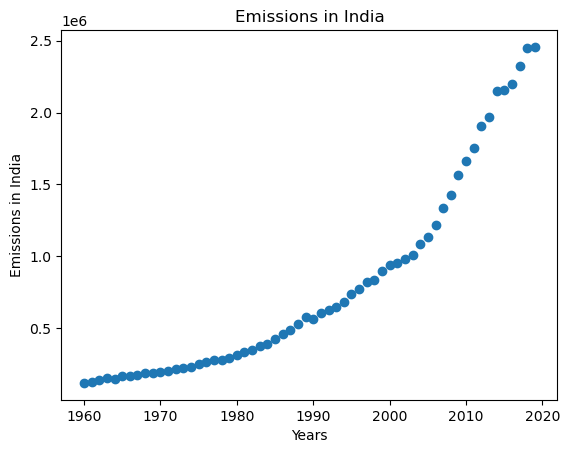

```python
import matplotlib.pyplot as plt
import pandas as pd
iran_emissions = pd.read_csv("data/india_co2_emissions.csv")
variable_names = ["year", "total_emissions"]

plt.scatter(iran_emissions["year"], iran_emissions["total_emissions"])
plt.title("Emissions in India")
plt.xlabel("Years")
plt.ylabel("Emissions in India")
plt.show()
```

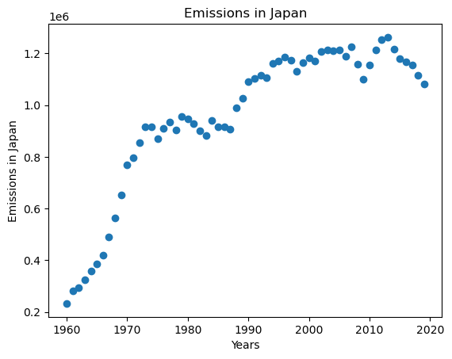

```python
# Write your answer
import matplotlib.pyplot as plt
import pandas as pd
iran_emissions = pd.read_csv("data/japan_co2_emissions.csv")
variable_names = ["year", "total_emissions"]

plt.scatter(iran_emissions["year"], iran_emissions["total_emissions"])
plt.title("Emissions in Japan")
plt.xlabel("Years")
plt.ylabel("Emissions in Japan")
plt.show()
```